# Risk Factor Analysis

## Outcome Variable

**Outcome Variable:** wasted

## Predictor Variables

**Intervention Variable:** nhh

**Adjustment Set:**

unadjusted

## Stratifying Variables

The analysis was stratified on these variable(s):

- agecat
- studyid
- country

## Data Summary

| agecat | studyid | country | nhh | wasted | n_cell | n |
| --- | --- | --- | --- | --- | --- | --- |
| Birth | ki1000108-IRC | INDIA | 3 or less | 0 | 35 | 343 |
| Birth | ki1000108-IRC | INDIA | 3 or less | 1 | 17 | 343 |
| Birth | ki1000108-IRC | INDIA | 4-5 | 0 | 99 | 343 |
| Birth | ki1000108-IRC | INDIA | 4-5 | 1 | 32 | 343 |
| Birth | ki1000108-IRC | INDIA | 6-7 | 0 | 68 | 343 |
| Birth | ki1000108-IRC | INDIA | 6-7 | 1 | 16 | 343 |
| Birth | ki1000108-IRC | INDIA | 8+ | 0 | 49 | 343 |
| Birth | ki1000108-IRC | INDIA | 8+ | 1 | 27 | 343 |
| Birth | ki1017093-NIH-Birth | BANGLADESH | 3 or less | 0 | 5 | 28 |
| Birth | ki1017093-NIH-Birth | BANGLADESH | 3 or less | 1 | 2 | 28 |
| Birth | ki1017093-NIH-Birth | BANGLADESH | 4-5 | 0 | 10 | 28 |
| Birth | ki1017093-NIH-Birth | BANGLADESH | 4-5 | 1 | 1 | 28 |
| Birth | ki1017093-NIH-Birth | BANGLADESH | 6-7 | 0 | 5 | 28 |
| Birth | ki1017093-NIH-Birth | BANGLADESH | 6-7 | 1 | 2 | 28 |
| Birth | ki1017093-NIH-Birth | BANGLADESH | 8+ | 0 | 1 | 28 |
| Birth | ki1017093-NIH-Birth | BANGLADESH | 8+ | 1 | 2 | 28 |
| Birth | ki1017093c-NIH-Crypto | BANGLADESH | 3 or less | 0 | 6 | 23 |
| Birth | ki1017093c-NIH-Crypto | BANGLADESH | 3 or less | 1 | 2 | 23 |
| Birth | ki1017093c-NIH-Crypto | BANGLADESH | 4-5 | 0 | 7 | 23 |
| Birth | ki1017093c-NIH-Crypto | BANGLADESH | 4-5 | 1 | 0 | 23 |
| Birth | ki1017093c-NIH-Crypto | BANGLADESH | 6-7 | 0 | 4 | 23 |
| Birth | ki1017093c-NIH-Crypto | BANGLADESH | 6-7 | 1 | 1 | 23 |
| Birth | ki1017093c-NIH-Crypto | BANGLADESH | 8+ | 0 | 3 | 23 |
| Birth | ki1017093c-NIH-Crypto | BANGLADESH | 8+ | 1 | 0 | 23 |
| 6 months | ki1000108-IRC | INDIA | 3 or less | 0 | 50 | 408 |
| 6 months | ki1000108-IRC | INDIA | 3 or less | 1 | 7 | 408 |
| 6 months | ki1000108-IRC | INDIA | 4-5 | 0 | 140 | 408 |
| 6 months | ki1000108-IRC | INDIA | 4-5 | 1 | 17 | 408 |
| 6 months | ki1000108-IRC | INDIA | 6-7 | 0 | 92 | 408 |
| 6 months | ki1000108-IRC | INDIA | 6-7 | 1 | 15 | 408 |

[output cut: 82 more lines]

The following strata were considered:

- agecat: 24 months, studyid: ki1000108-IRC, country: INDIA
- agecat: 24 months, studyid: ki1017093-NIH-Birth, country: BANGLADESH
- agecat: 24 months, studyid: ki1017093b-PROVIDE, country: BANGLADESH
- agecat: 24 months, studyid: ki1017093c-NIH-Crypto, country: BANGLADESH
- agecat: 24 months, studyid: ki1148112-LCNI-5, country: MALAWI
- agecat: 6 months, studyid: ki1000108-IRC, country: INDIA
- agecat: 6 months, studyid: ki1000304b-SAS-FoodSuppl, country: INDIA
- agecat: 6 months, studyid: ki1017093-NIH-Birth, country: BANGLADESH
- agecat: 6 months, studyid: ki1017093b-PROVIDE, country: BANGLADESH
- agecat: 6 months, studyid: ki1017093c-NIH-Crypto, country: BANGLADESH
- agecat: 6 months, studyid: ki1148112-LCNI-5, country: MALAWI
- agecat: Birth, studyid: ki1000108-IRC, country: INDIA
- agecat: Birth, studyid: ki1017093-NIH-Birth, country: BANGLADESH
- agecat: Birth, studyid: ki1017093c-NIH-Crypto, country: BANGLADESH

### Dropped Strata

Some strata were dropped due to rare outcomes:

- agecat: Birth, studyid: ki1017093-NIH-Birth, country: BANGLADESH
- agecat: Birth, studyid: ki1017093c-NIH-Crypto, country: BANGLADESH
- agecat: 6 months, studyid: ki1000304b-SAS-FoodSuppl, country: INDIA
- agecat: 6 months, studyid: ki1017093-NIH-Birth, country: BANGLADESH
- agecat: 6 months, studyid: ki1017093b-PROVIDE, country: BANGLADESH
- agecat: 6 months, studyid: ki1017093c-NIH-Crypto, country: BANGLADESH
- agecat: 6 months, studyid: ki1148112-LCNI-5, country: MALAWI
- agecat: 24 months, studyid: ki1000108-IRC, country: INDIA
- agecat: 24 months, studyid: ki1017093c-NIH-Crypto, country: BANGLADESH
- agecat: 24 months, studyid: ki1148112-LCNI-5, country: MALAWI

## Methods Detail

We’re interested in the causal parameters $E[Y_a]$ for all values of $a \in \mathcal{A}$. These parameters represent the mean outcome if, possibly contrary to fact, we intervened to set all units to have $A=a$. Under the randomization and positivity assumptions, these are identified by the statistical parameters $\psi_a=E_W[E_{Y|A,W}(Y|A=a,W)]$. In addition, we’re interested in the mean of $Y$, $E[Y]$ under no intervention (the observed mean). We will estimate these parameters by using SuperLearner to fit the relevant likelihood factors – $E_{Y|A,W}(Y|A=a,W)$ and $p(A=a|W)$, and then updating our likelihood fit using a joint TMLE.

For unadjusted analyses ($W=\{\}$), initial likelihoods were estimated using Lrnr_glm to estimate the simple $E(Y|A)$ and Lrnr_mean to estimate $p(A)$. For adjusted analyses, a small library containing Lrnr_glmnet, Lrnr_xgboost, and Lrnr_mean was used.

Having estimated these parameters, we will then use the delta method to estimate relative risks and attributable risks relative to a prespecified baseline level of $A$.

# Results Detail

## Results Plots

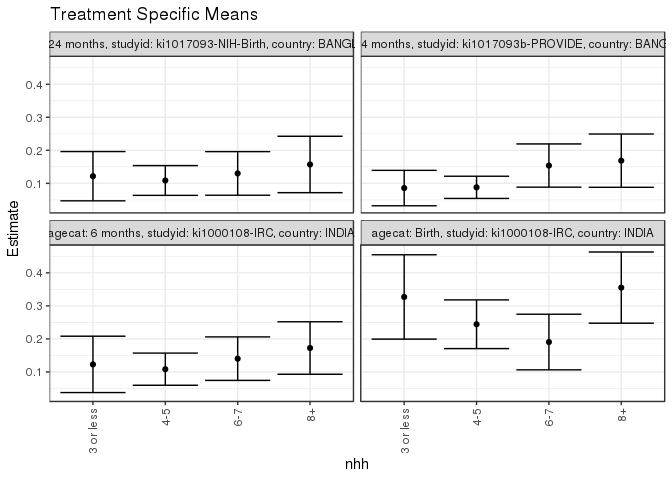

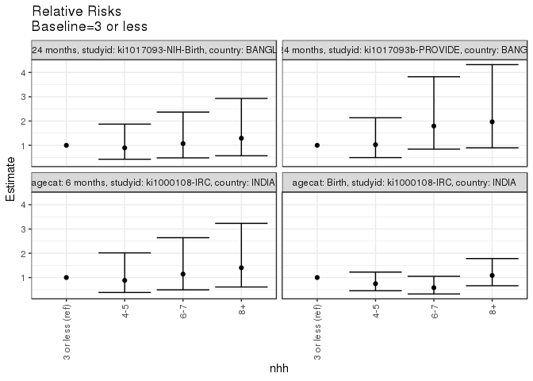

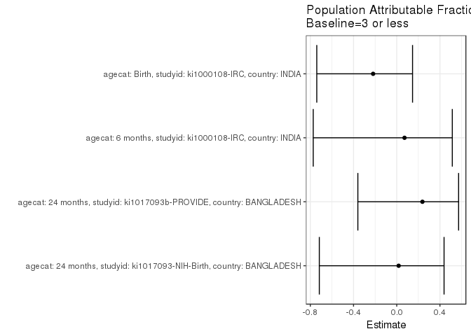

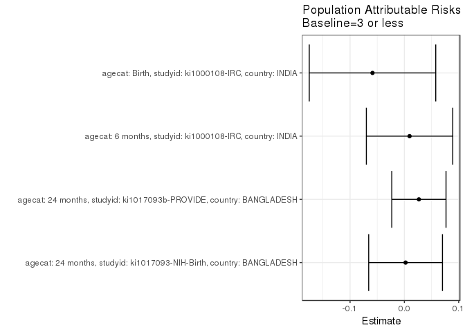

## Results Table

### Parameter: TSM

| agecat | studyid | country | intervention_level | baseline_level | estimate | ci_lower | ci_upper |
| --- | --- | --- | --- | --- | --- | --- | --- |
| Birth | ki1000108-IRC | INDIA | 3 or less | NA | 0.3269231 | 0.1992393 | 0.4546068 |
| Birth | ki1000108-IRC | INDIA | 4-5 | NA | 0.2442748 | 0.1705917 | 0.3179579 |
| Birth | ki1000108-IRC | INDIA | 6-7 | NA | 0.1904762 | 0.1063797 | 0.2745726 |
| Birth | ki1000108-IRC | INDIA | 8+ | NA | 0.3552632 | 0.2475071 | 0.4630192 |
| 6 months | ki1000108-IRC | INDIA | 3 or less | NA | 0.1228070 | 0.0374965 | 0.2081176 |
| 6 months | ki1000108-IRC | INDIA | 4-5 | NA | 0.1082803 | 0.0596149 | 0.1569456 |
| 6 months | ki1000108-IRC | INDIA | 6-7 | NA | 0.1401869 | 0.0743234 | 0.2060504 |
| 6 months | ki1000108-IRC | INDIA | 8+ | NA | 0.1724138 | 0.0929418 | 0.2518858 |
| 24 months | ki1017093-NIH-Birth | BANGLADESH | 3 or less | NA | 0.1216216 | 0.0470650 | 0.1961783 |
| 24 months | ki1017093-NIH-Birth | BANGLADESH | 4-5 | NA | 0.1086957 | 0.0636694 | 0.1537219 |
| 24 months | ki1017093-NIH-Birth | BANGLADESH | 6-7 | NA | 0.1300000 | 0.0640086 | 0.1959914 |
| 24 months | ki1017093-NIH-Birth | BANGLADESH | 8+ | NA | 0.1571429 | 0.0717874 | 0.2424983 |
| 24 months | ki1017093b-PROVIDE | BANGLADESH | 3 or less | NA | 0.0857143 | 0.0321226 | 0.1393059 |
| 24 months | ki1017093b-PROVIDE | BANGLADESH | 4-5 | NA | 0.0879121 | 0.0542930 | 0.1215311 |
| 24 months | ki1017093b-PROVIDE | BANGLADESH | 6-7 | NA | 0.1538462 | 0.0884128 | 0.2192795 |
| 24 months | ki1017093b-PROVIDE | BANGLADESH | 8+ | NA | 0.1686747 | 0.0880449 | 0.2493045 |

### Parameter: E(Y)

| agecat | studyid | country | intervention_level | baseline_level | estimate | ci_lower | ci_upper |
| --- | --- | --- | --- | --- | --- | --- | --- |
| Birth | ki1000108-IRC | INDIA | NA | NA | 0.2682216 | 0.2212677 | 0.3151755 |
| 6 months | ki1000108-IRC | INDIA | NA | NA | 0.1323529 | 0.0994307 | 0.1652752 |
| 24 months | ki1017093-NIH-Birth | BANGLADESH | NA | NA | 0.1238318 | 0.0925894 | 0.1550741 |
| 24 months | ki1017093b-PROVIDE | BANGLADESH | NA | NA | 0.1124567 | 0.0866788 | 0.1382347 |

### Parameter: RR

| agecat | studyid | country | intervention_level | baseline_level | estimate | ci_lower | ci_upper |
| --- | --- | --- | --- | --- | --- | --- | --- |
| Birth | ki1000108-IRC | INDIA | 3 or less | 3 or less | 1.0000000 | 1.0000000 | 1.000000 |
| Birth | ki1000108-IRC | INDIA | 4-5 | 3 or less | 0.7471935 | 0.4561589 | 1.223912 |
| Birth | ki1000108-IRC | INDIA | 6-7 | 3 or less | 0.5826331 | 0.3231429 | 1.050499 |
| Birth | ki1000108-IRC | INDIA | 8+ | 3 or less | 1.0866873 | 0.6627393 | 1.781831 |
| 6 months | ki1000108-IRC | INDIA | 3 or less | 3 or less | 1.0000000 | 1.0000000 | 1.000000 |
| 6 months | ki1000108-IRC | INDIA | 4-5 | 3 or less | 0.8817106 | 0.3854765 | 2.016760 |
| 6 months | ki1000108-IRC | INDIA | 6-7 | 3 or less | 1.1415220 | 0.4934812 | 2.640572 |
| 6 months | ki1000108-IRC | INDIA | 8+ | 3 or less | 1.4039409 | 0.6099352 | 3.231573 |
| 24 months | ki1017093-NIH-Birth | BANGLADESH | 3 or less | 3 or less | 1.0000000 | 1.0000000 | 1.000000 |
| 24 months | ki1017093-NIH-Birth | BANGLADESH | 4-5 | 3 or less | 0.8937198 | 0.4264662 | 1.872915 |
| 24 months | ki1017093-NIH-Birth | BANGLADESH | 6-7 | 3 or less | 1.0688889 | 0.4822491 | 2.369156 |
| 24 months | ki1017093-NIH-Birth | BANGLADESH | 8+ | 3 or less | 1.2920635 | 0.5696110 | 2.930821 |
| 24 months | ki1017093b-PROVIDE | BANGLADESH | 3 or less | 3 or less | 1.0000000 | 1.0000000 | 1.000000 |
| 24 months | ki1017093b-PROVIDE | BANGLADESH | 4-5 | 3 or less | 1.0256410 | 0.4928277 | 2.134498 |
| 24 months | ki1017093b-PROVIDE | BANGLADESH | 6-7 | 3 or less | 1.7948718 | 0.8426106 | 3.823314 |
| 24 months | ki1017093b-PROVIDE | BANGLADESH | 8+ | 3 or less | 1.9678715 | 0.8957612 | 4.323159 |

### Parameter: PAR

| agecat | studyid | country | intervention_level | baseline_level | estimate | ci_lower | ci_upper |
| --- | --- | --- | --- | --- | --- | --- | --- |
| Birth | ki1000108-IRC | INDIA | 3 or less | NA | -0.0587015 | -0.1751686 | 0.0577656 |
| 6 months | ki1000108-IRC | INDIA | 3 or less | NA | 0.0095459 | -0.0700043 | 0.0890961 |
| 24 months | ki1017093-NIH-Birth | BANGLADESH | 3 or less | NA | 0.0022102 | -0.0657061 | 0.0701264 |
| 24 months | ki1017093b-PROVIDE | BANGLADESH | 3 or less | NA | 0.0267425 | -0.0231883 | 0.0766732 |

### Parameter: PAF

| agecat | studyid | country | intervention_level | baseline_level | estimate | ci_lower | ci_upper |
| --- | --- | --- | --- | --- | --- | --- | --- |
| Birth | ki1000108-IRC | INDIA | 3 or less | NA | -0.2188545 | -0.7402278 | 0.1463150 |
| 6 months | ki1000108-IRC | INDIA | 3 or less | NA | 0.0721248 | -0.7730496 | 0.5144228 |
| 24 months | ki1017093-NIH-Birth | BANGLADESH | 3 or less | NA | 0.0178480 | -0.7166926 | 0.4380925 |
| 24 months | ki1017093b-PROVIDE | BANGLADESH | 3 or less | NA | 0.2378022 | -0.3599166 | 0.5728080 |